# Análisis de datos de Microarrays PEC1 - Análisis de Datos ómicos

Emilio Alarcón Martín

3 de mayo, 2020

# Introducción

## Objetivo

El objetivo de este trabajo es realizar un análisis de datos de microarrays del set de datos seleccionado, GDS2300. Consta de 6 muestras de ovocitos de ratón. Compararemos la expresión génica de 3 ovocitos en estadio de metafase II con 3 ovocitos en estadio de vesícula germinal.

## Abstract

En este artículo se buscó identificar y caracterizar las transcripciones que están degradadas frente a las que están estables durante la transición de la vesícula germinal (VG) transcriptivamente silenciosa a la metafase II (MII) mediante un enfoque de microarrays. Se utilizó un sistema de amplificación de la transcripción de los ovocitos utilizando cebado interno y de 3’-poly(A) para minimizar el impacto de las variaciones complejas en la poliadenilación de la transcripción que prevalecen durante esta transición. Las transcripciones fueron identificadas y cuantificadas usando el genoma del ratón Affymetrix 430 v2.0 GeneChip.

[*Su, Y. Q., Sugiura, K., Woo, Y., Wigglesworth, K., Kamdar, S., Affourtit, J., & Eppig, J. J. (2007). Selective degradation of transcripts during meiotic maturation of mouse oocytes. Developmental biology, 302(1), 104-117.*](https://www.ncbi.nlm.nih.gov/pubmed/17022963)

## Puesta a punto de Rstudio

Se plantea aquí la instalación de los paquetes y su activación en Rstudio para su uso en esta actividad. Podrían no coincidir las versiones de los paquetes con las realizadas posteriormente.

```r
> if (!requireNamespace("BiocManager", quietly = TRUE))
+     install.packages("BiocManager")
> BiocManager::install()
>
>
> libraries <- c("affy",
+                "annaffy",
+                "annotate",
+                "affyPLM",
+                "affyQCReport",
+                "genefilter",
+                "limma",
+                "org.Mm.eg.db",
+                "mouse4302.db",
+                "DOSE",
+                "clusterProfiler",
+                "pathview",
+                "Category",
+                "GO.db",
+                "GOstats",
+                "gplots")
>
>
> check.libraries <- is.element(libraries, installed.packages()[, 1])==FALSE
> libraries.to.install <- libraries[check.libraries]
> if (length(libraries.to.install!=0)) {
+ if (!requireNamespace("BiocManager", quietly = TRUE))
+   install.packages("BiocManager")
+ BiocManager::install(libraries.to.install)
+ }
>
> for (i in libraries) {
+   library(i, character.only = TRUE)
+ }
```

# Obtención y lectura de los datos

Al igual que en el ejercicio planteado, en primer lugar se asigna un directorio de trabajo a la variable **workingDir**. Dentro de éste, se creará un subdirectorio denominado **“data”** para almacenar los datos y un directorio **“results”** para los resultados.

Los datos pueden verse en este enlace [este link](https://www.ncbi.nlm.nih.gov/geo/query/acc.cgi?acc=GSE5668) y descargarse directamente desde [este link](https://ftp.ncbi.nlm.nih.gov/geo/series/GSE5nnn/GSE5668/soft/) y [este link](https://www.ncbi.nlm.nih.gov/geo/download/?acc=GSE5668&format=file). Será necesario descomprimir los archivos e introducirlos en el subdirectorio **“data”**.

El código, junto con los resultados obtenidos, [pueden descargarse desde este link a github](https://github.com/Alarcon-Martin-E/PEC1_Analisis_Omicos).

```r
> setwd("C:/Users/Emilio/Desktop/PEC 1 Ómicas abril 2020")
> workingdir <- getwd()
> dataDir <- file.path(workingdir, "data")
> resultsDir <- file.path(workingdir,"results")
> celfilesDir <- file.path(workingdir,"celfiles")
```

## Lectura de los datos

Las muestras “GSM132592.CEL.gz” “GSM132657.CEL.gz” “GSM132658.CEL.gz” “GSM132659.CEL.gz” “GSM132660.CEL.gz” “GSM132661.CEL.gz” se corresponden respectivamente a “Vesícula germinal 1”, “Vesícula germinal 2”, “Vesícula germinal 3”, “Metafase II 1”, “Metafase II 2”, “Metafase II 3”. Se asignan también los colores para estos dos grupos que serán empleados en el preprocesado de los datos.

```r
> setwd(dataDir)
> affy.data <- ReadAffy()
> show(affy.data)
```

```
AffyBatch object
size of arrays=1002x1002 features (20 kb)
cdf=Mouse430_2 (45101 affyids)
number of samples=6
number of genes=45101
annotation=mouse4302
notes=
```

```r
> colnames(affy.data)
```

```
[1] "GSM132592.CEL" "GSM132657.CEL" "GSM132658.CEL" "GSM132659.CEL"
[5] "GSM132660.CEL" "GSM132661.CEL"
```

```r
> info <- readLines(file.path(dataDir,"GDS2300_full.soft"), n=70)
> exprs <- read.csv(file.path(dataDir, "GDS2300_full.soft"), skip=68,
+                 header=TRUE,sep="\t",row.names = 1)
>
> colnames(exprs)
```

```
 [1] "IDENTIFIER"            "GSM132592"             "GSM132657"
 [4] "GSM132658"             "GSM132659"             "GSM132660"
 [7] "GSM132661"             "Gene.title"            "Gene.symbol"
[10] "Gene.ID"               "UniGene.title"         "UniGene.symbol"
[13] "UniGene.ID"            "Nucleotide.Title"      "GI"
[16] "GenBank.Accession"     "Platform_CLONEID"      "Platform_ORF"
[19] "Platform_SPOTID"       "Chromosome.location"   "Chromosome.annotation"
[22] "GO.Function"           "GO.Process"            "GO.Component"
[25] "GO.Function.ID"        "GO.Process.ID"         "GO.Component.ID"
```

```r
> dim(exprs)
```

```
[1] 45102    27
```

```r
> colores <- c(rep("#FF0000",3), c(rep("#0000FF",3)))
```

# Preprocesado: Exploración, Control de Calidad y Normalización

## Exploración de los datos

### Gráfico de densidad de los arrays

Permite hacerse una idea de si las distribuciones de los distintos arrays son similares en forma y posición. Existe una ligera diferencia entre “GermVes” y “MII”, pero podemos concluir que la distribución de los arrays es similar.

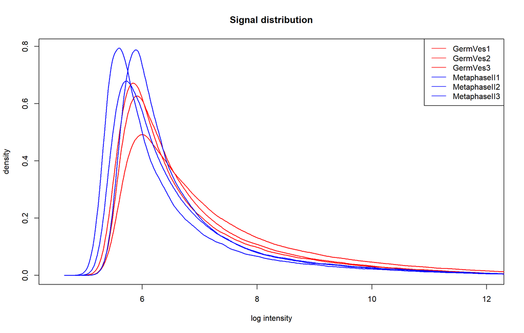

```r
> affy.data$sample <- c("GermVes1","GermVes2","GermVes3",
+                     "MetaphaseII1","MetaphaseII2", "MetaphaseII3")
> info <- data.frame(grupo = c(4,4,4,5,5,5))
> sampleNames <- pData(affy.data)$sample
> hist(affy.data, main = "Signal distribution", col = colores,
+      lty = 1:ncol(info), xlim = c(4.5,12), lwd = 1.5)
> legend (x = "topright", legend = sampleNames,
+         col = colores, lty = 1:ncol(info))
```

### Diagrama de cajas

Muestra información similar al gráfico de densidad, facilitando la comparación entre distribuciones.

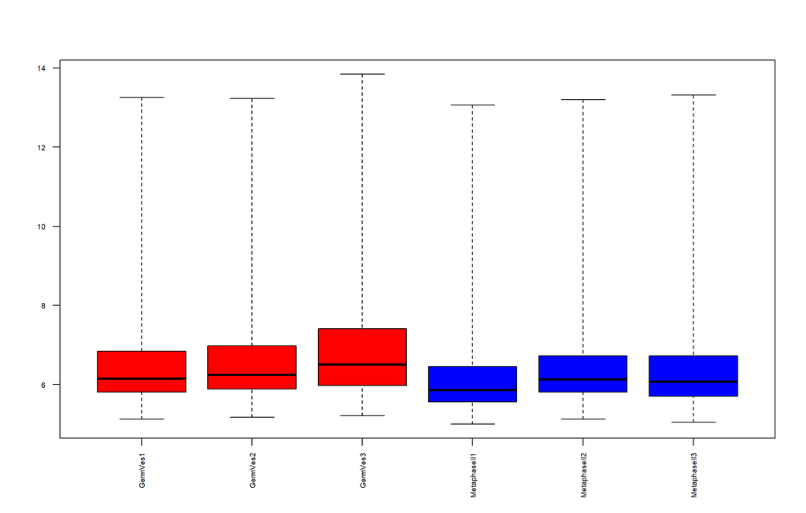

```r
> boxplot(affy.data, cex.axis=0.6, col = colores, las = 2,
+         names = sampleNames)
```

### Análisis de componentes principales (PCA)

Empleando el análisis de componentes principales detectamos si las muestras se agrupan por grupos de manera coherente (MII frente a GermVes). El PC1 separa bastante bien los grupos, lo cual es importante porque agrupa un porcentaje muy elevado de la varianza (73%). El PC2 presenta agrupa un porcentaje menor de la varianza, y principalmente separa réplicas (13.3%). Germvers3 se aleja ligeramente del resto, pero no creo que sea una diferencia especialmente elevada. Podemos considerar el enfoque de PC como bueno, ya que en total, recoje el 86.3% de la varianza de las muestras.

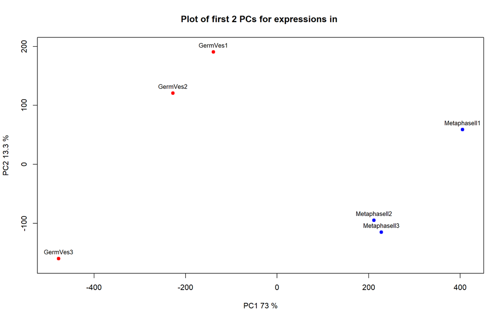

```r
> logaffy <- log2(exprs(affy.data))
> plotPCA <- function(X, labels = affy.data$sample, colors = colores,
+                       dataDesc = "", scale = FALSE)
+ {
+ pcX <- prcomp(t(X), scale = scale)
+ loads <- round(pcX$sdev^2/sum(pcX$sdev^2)*100, 1)
+ xlab <- c(paste("PC1",loads[1],"%"))
+ ylab <- c(paste("PC2",loads[2],"%"))
+ if (is.null(colors)) colors=1
+ plot(pcX$x[,1:2], xlab = xlab, ylab = ylab, col = colors, pch = 19,
+ xlim = c(min(pcX$x[,1])-10, max(pcX$x[,1])+10),
+ ylim = c(min(pcX$x[,2])-10, max(pcX$x[,2])+10),
+ )
+ text(pcX$x[,1], pcX$x[,2], labels, pos=3, cex=0.8)
+ title(paste("Plot of first 2 PCs for expressions in", dataDesc, sep=" "), cex = 0.8)
+ }
> plotPCA(logaffy)
```

## Control de calidad específico para microarrays

### Dendrograma

Dendrograma resultante de un agrupamiento jerárquico. De nuevo, GermVesc3 no se agrupa con las sus muestras de GermVesc, lo que puede significar que hay cierta variación que puede deberse a procedimiento experimental, Esta heterogeneidad de la mueestra no debería suponer un problema mayor después de la normalización y filtraje de los datos.

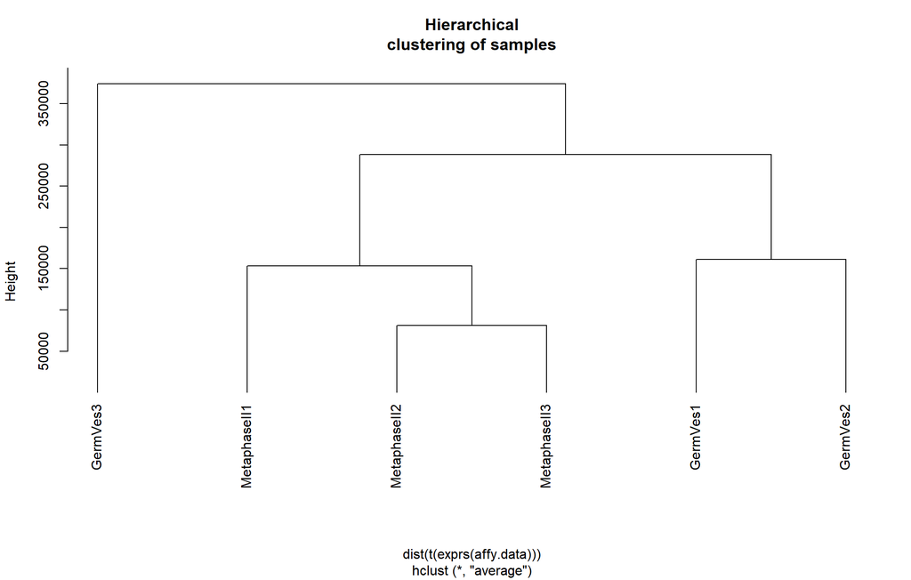

```r
> clust.euclid.average <- hclust(dist(t(exprs(affy.data))), method = "average")
> plot(clust.euclid.average, labels = sampleNames, main = "Hierarchical
+ clustering of samples", hang = -1)
```

### Gráfico de degradación

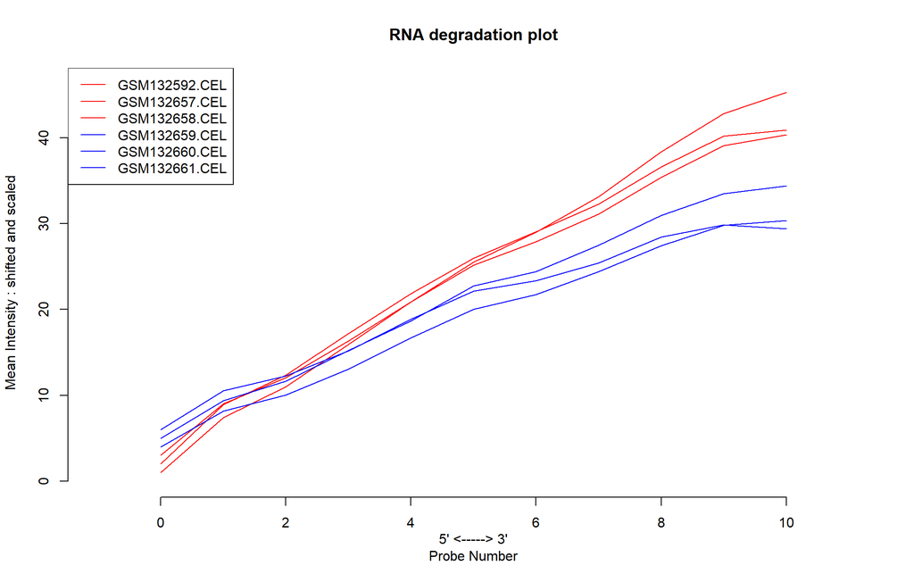

```r
> deg <- AffyRNAdeg(affy.data)
> cols <- sample(colors(), nrow(pData(affy.data)))
> plotAffyRNAdeg(deg, col=colores)
> legend(legend = sampleNames(affy.data), x = "topleft", lty = 1, col = colores)
```

### Gráfico de expresiones relativas (RLE)

Gráfico de expresiones relativas (RLE) resultante del análisis basado en modelos (PLM). Las muestras son simétricas y similares lo que sugiera una calidad aceptable de los datos

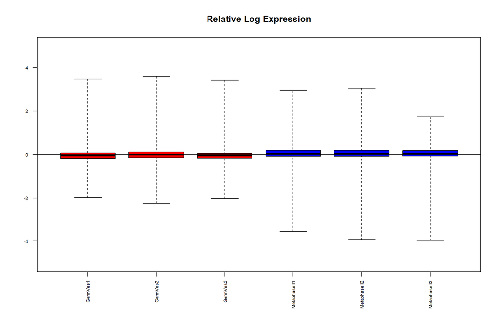

```r
> computePLM <- T
> if(computePLM){
+ Pset <- fitPLM(affy.data)
+ save(Pset, file = file.path(workingdir,"PLM.Rda"))
+ }else{
+ load (file = file.path(workingdir,"PLM.Rda"))
+ }
> RLE(Pset, main = "Relative Log Expression", names = sampleNames,
+ las = 2, col = colores, cex.axis = 0.6, ylim = c(-5,5))
```

# Normalización

En el boxplot de los valores normalizados se observa que los valores en una situación que permite su comparación

```r
> ovo <- rma(affy.data)
```

```
Background correcting
Normalizing
Calculating Expression
```

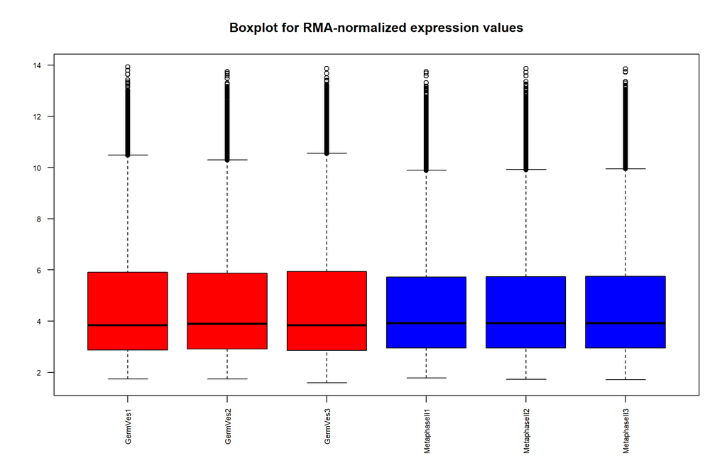

```r
> ovo.rma <- exprs(ovo)
> boxplot(ovo.rma,main="Boxplot for RMA-normalized expression values",
+ names = sampleNames, cex.axis = 0.7, col = colores,las = 2)
```

```r
> colnames(ovo.rma) <- c("GermVes1","GermVes2","GermVes3","MII1","MII2","MII3")
> dim(ovo.rma)
```

```
[1] 45101     6
```

# Selección de genes con expresión diferencial

## Matriz de diseño y matriz de contraste

La matriz de diseño aporta asignación de cada muestra a un grupo (cada fila contiene un uno en la columna del grupo y cero en el resto)

La matriz de contrastes describe las comparaciones entre grupos. En este caso la matriz de comparación es muy simple, pero de forma habitual consta de tantas columnas como comparaciones y filas como grupos.

```r
> design <- matrix(c(1,1,1,0,0,0,0,0,0,1,1,1), nrow=6)
> colnames(design) <- c("GermVes", "Metaphase")
> rownames(design) <- c("GermVes1", "GermVes2", "GermVes3", "MII1", "MII2",   "MII3")
> design
```

```
         GermVes Metaphase
GermVes1       1         0
GermVes2       1         0
GermVes3       1         0
MII1           0         1
MII2           0         1
MII3           0         1
```

```r
> cont.matrix <- makeContrasts (MetaphaseII = (Metaphase-GermVes), levels=design)
> cont.matrix
```

```
           Contrasts
Levels      MetaphaseII
  GermVes            -1
  Metaphase           1
```

## Estimación del modelo y selección de genes

Generamos el modelo lineal a partir de los datos normalizados y las matrices. En *limma* amplía el análisis empleando modelos de Bayes empíricos, combinando información la matriz de datos y de cada gen individual, lo que obtiene estimaciones de error mejoradas. Para controlar el porcentaje de falsos positivos, los p-valores se ajustan utilizando el metodo de Benjamini y Hochberg.

Como método de visualización, con el volcanoplot podemos apreciar los genes más interesantes (log2 Fold Change neto elevado para la significación biológica y −log10(P−value) elevado para la estadística)

En el gráfico, podemos la asimetría hacia la izquierda, lo que indica un menor número genes transcripcionalmente activos en metafase II comparados con el estadio de vesícula germinal. Esto es coherente ya que en Metafase II, la heterocromatina está compactada formando la placa metafásica ecuatorial, siendo esta apenas accesible a la maquinaria de transcripción.

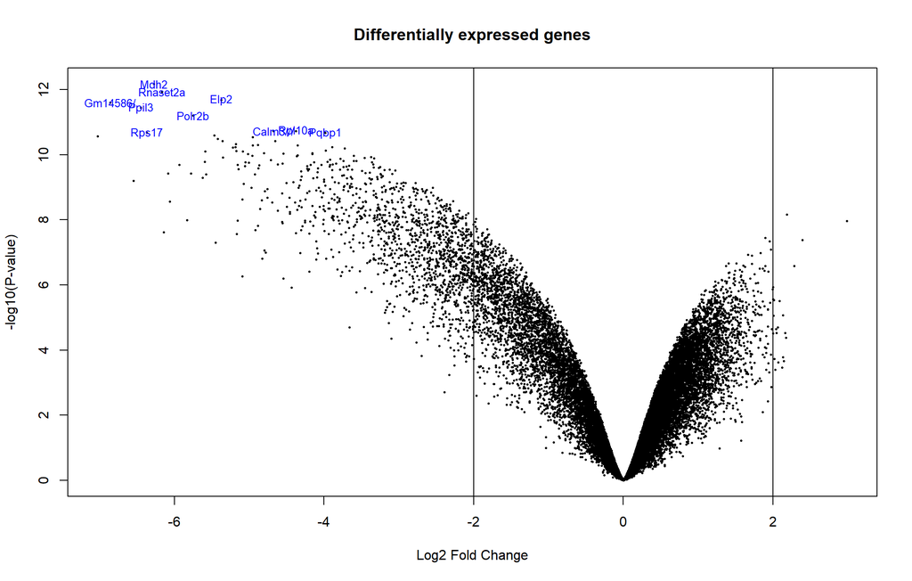

```r
> fit <- lmFit(ovo.rma, design)
> fit.main <- contrasts.fit(fit, cont.matrix)
> fit.main <- eBayes(fit.main)
> topTabMII <- topTable (fit.main, number = nrow(fit.main), coef = "MetaphaseII", adjust="fdr")
> coefnum=1
> volcanoplot(fit.main, coef = 1, highlight = 10, names = exprs$Gene.symbol ,
+             style= "p-value", main = "Differentially expressed genes")
> abline(v = c(-2,2))
```

## Principales genes expresados diferencialmente

Para ver con más detalle los genes más relevantes, podría analizarse la tabla **topTabMII2** que se crea a continuación.

```r
> topTabMII2 <- topTable (fit.main, number=nrow(fit.main), adjust="fdr", genelist = exprs)
> colnames(topTabMII2)
```

```
 [1] "IDENTIFIER"            "GSM132592"             "GSM132657"
 [4] "GSM132658"             "GSM132659"             "GSM132660"
 [7] "GSM132661"             "Gene.title"            "Gene.symbol"
[10] "Gene.ID"               "UniGene.title"         "UniGene.symbol"
[13] "UniGene.ID"            "Nucleotide.Title"      "GI"
[16] "GenBank.Accession"     "Platform_CLONEID"      "Platform_ORF"
[19] "Platform_SPOTID"       "Chromosome.location"   "Chromosome.annotation"
[22] "GO.Function"           "GO.Process"            "GO.Component"
[25] "GO.Function.ID"        "GO.Process.ID"         "GO.Component.ID"
[28] "logFC"                 "AveExpr"               "t"
[31] "P.Value"               "adj.P.Val"             "B"
```

```r
> str(topTabMII2)
```

```
'data.frame':   45101 obs. of  33 variables:
 $ IDENTIFIER           : Factor w/ 26682 levels "","--Control",..: 18067 21851 13027 14537 20737 20646 21983 10112 22039 20842 ...
 $ GSM132592            : Factor w/ 7079 levels "","1.85027","1.88006",..: 128 399 448 343 129 310 254 361 371 6462 ...
 $ GSM132657            : Factor w/ 7079 levels "","1.85027","1.88006",..: 102 402 447 365 182 339 237 362 393 6457 ...
 $ GSM132658            : Factor w/ 7079 levels "","1.85027","1.88006",..: 82 393 446 334 83 304 204 351 369 6379 ...
 $ GSM132659            : Factor w/ 7079 levels "","1.85027","1.88006",..: 2287 4464 5812 3215 2334 3976 4748 5148 4022 2862 ...
 $ GSM132660            : Factor w/ 7079 levels "","1.85027","1.88006",..: 2230 4357 5730 3292 2317 4131 4771 5327 3662 2651 ...
 $ GSM132661            : Factor w/ 7079 levels "","1.85027","1.88006",..: 2401 4216 5742 3148 1968 3836 4794 5147 4187 2871 ...
 $ Gene.title           : Factor w/ 21709 levels "","1-acylglycerol-3-phosphate O-acyltransferase 1 (lysophosphatidic acid acyltransferase, alpha)",..: 8902 13884 4611 11930 10975 11545 13906 1847 13953 11514 ...
 $ Gene.symbol          : Factor w/ 21723 levels "","0610005C13Rik",..: 13048 16863 7897 9421 15742 15651 16998 4957 17055 15848 ...
 $ Gene.ID              : Factor w/ 21723 levels "","100008567",..: 5304 31 14083 200 17062 9118 6408 2841 6430 13411 ...
 $ UniGene.title        : Factor w/ 223 levels "","2-cell-stage, variable group, member 3",..: 1 1 1 1 1 1 1 1 1 1 ...
 $ UniGene.symbol       : Factor w/ 106 levels "","1700023F02Rik",..: 1 1 1 1 1 1 1 1 1 1 ...
 $ UniGene.ID           : Factor w/ 1792 levels "","Mm.100895",..: 1 1 1 1 1 1 1 1 1 1 ...
 $ Nucleotide.Title     : Factor w/ 36271 levels "","0104-78 Mouse E14.5 retina lambda ZAP II Library Mus musculus cDNA, mRNA sequence",..: 1493 1943 6318 11633 12728 34858 20607 23531 29706 4636 ...
```

[output cut: 19 more lines]

```r
> topTabMII2[1:10,c(28:33)]
```

|  | logFC | AveExpr | t | P.Value | adj.P.Val | B |
| --- | --- | --- | --- | --- | --- | --- |
| 1433984_a_at | -6.274365 | 7.061497 | -63.04831 | 6.601710e-13 | 2.599082e-08 | 19.20462 |
| 1456012_x_at | -6.165310 | 9.002740 | -59.13856 | 1.152561e-12 | 2.599082e-08 | 18.84512 |
| 1438179_s_at | -5.374540 | 10.474811 | -55.30899 | 2.063817e-12 | 2.817216e-08 | 18.44886 |
| 1437510_x_at | -6.858772 | 8.152061 | -54.10693 | 2.498584e-12 | 2.817216e-08 | 18.31438 |
| 1429627_at | -6.450413 | 7.057122 | -51.86092 | 3.612891e-12 | 3.258900e-08 | 18.04887 |
| 1433552_a_at | -5.749902 | 8.466528 | -48.67839 | 6.266436e-12 | 4.710376e-08 | 17.63789 |
| 1431177_a_at | -4.378015 | 8.585689 | -42.94001 | 1.863800e-11 | 9.613540e-08 | 16.77589 |
| 1423807_a_at | -4.679136 | 9.391626 | -42.85470 | 1.896275e-11 | 9.613540e-08 | 16.76174 |
| 1459986_a_at | -6.370147 | 8.711593 | -42.31275 | 2.117900e-11 | 9.613540e-08 | 16.67082 |
| 1456086_x_at | -3.984745 | 6.347380 | -42.28144 | 2.131558e-11 | 9.613540e-08 | 16.66552 |

# Post-procesado de las listas de genes obtenidas

Pueden ejecutarse diferentes tipos de análisis, encaminados a facilitar la interpretación. En este grupo se encuentran, entre otras:

- La anotación de las listas de genes en diversas bases de datos.
- La comparación entre las listas para determinar qué genes cambian simultaneamente en varias comparaciones.
- La visualización de todos los genes seleccionados en varias comparaciones para detectar grupos de genes con patrones de cambio similares.
- El análisis de significación biológica de las listas mediante análisis de enriquecimiento para detectar si las listas se encuentran enriquecidas en genes asociados a funciones o procesos biológicos determinados.

## Anotación de resultados

La identificación de los genes seleccionados puede resultar más sencilla para el especialista en un campo si se utilizan nombres estándar como “gene symbol”. Cada paquete de anotaciones tiene tablas de correspondencia entre los distintos tipos de identificadores, principalmente entre los del array y los de otras bases de datos. Para saber qué anotaciones están disponibles debe cargarse el paquete y llamar la función del mismo nombre.

```r
> geneList <- topTabMII2[,28]
> names(geneList) <- as.character(topTabMII2[,10])
> gene <- names(geneList)[abs(geneList) > 2]
> geneList <- sort(geneList, decreasing = TRUE)
> gene.df <- bitr(gene, fromType = "ENTREZID", toType = c("ENSEMBL", "SYMBOL"), OrgDb = org.Mm.eg.db)
> head(gene.df)
```

|  | ENTREZID | ENSEMBL | SYMBOL |
| --- | --- | --- | --- |
| 1 | 17448 | ENSMUSG00000019179 | Mdh2 |
| 3 | 58523 | ENSMUSG00000024271 | Elp2 |
| 5 | 70225 | ENSMUSG00000026035 | Ppil3 |
| 6 | 231329 | ENSMUSG00000029250 | Polr2b |
| 7 | 19896 | ENSMUSG00000037805 | Rpl10a |
| 9 | 20068 | ENSMUSG00000061787 | Rps17 |

## Visualización de la expresión diferencial. Heatmaps

Podemos observar que existen más genes regulados negativamente que positivamente en metafase II comparados con el estadio de vesicula germinal. Existen un total de 8162 genes que se ven expresados de forma diferencial.

```r
> res <- decideTests(fit.main, method = "separate", adjust.method = "fdr", p.value = 0.01)
> sum.res.rows <- apply(abs(res),1,sum)
> res.selected <- res[sum.res.rows != 0,]
> print(summary(res))
```

```
       MetaphaseII
Down          4321
NotSig       36939
Up            3841
```

A continuación, se muestran los resultados usando dos funciones *Heapmaps* distintas:

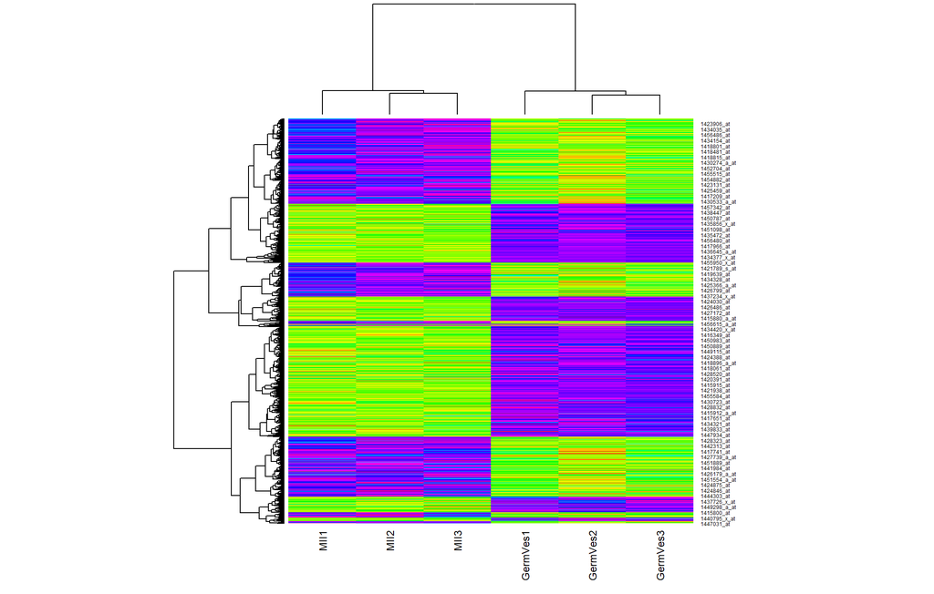

```r
> probeNames <- rownames(res)
> probeNames.selected <- probeNames[sum.res.rows != 0]
> exprs2cluster <- (ovo.rma)[probeNames.selected,]
> heatmap(exprs2cluster, col = rainbow(100), cexCol = 0.9)
```

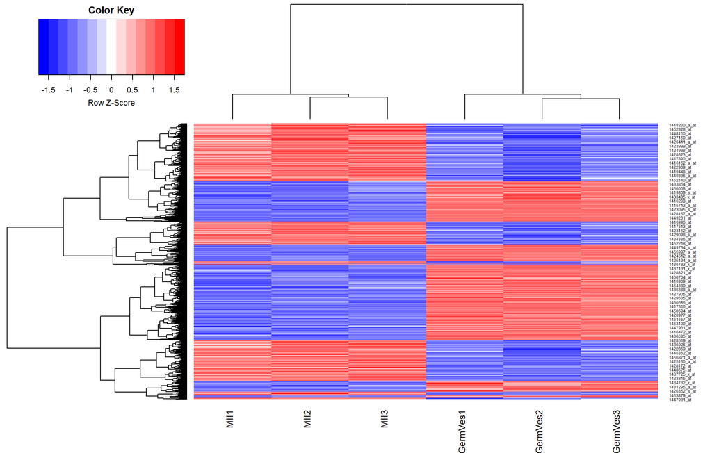

```r
> heatmap.2(exprs2cluster,
+           col = bluered, scale = "row", key = TRUE, symkey = FALSE,
+           density.info = "none", trace = "none", cexCol = 1, sepwidth = c(0.05, 0.05))
```

## Análisis de la significación biológica

### GO Set Enrichment utilizando la ontología: Biological Process.

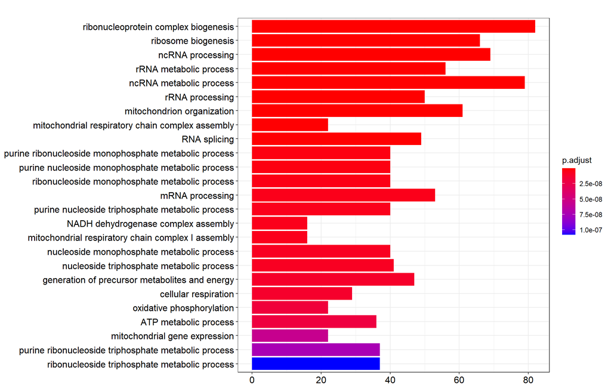

```r
> ego <- enrichGO(gene, OrgDb = "org.Mm.eg.db", ont="BP", readable=TRUE)
> barplot(ego, showCategory=25)
```

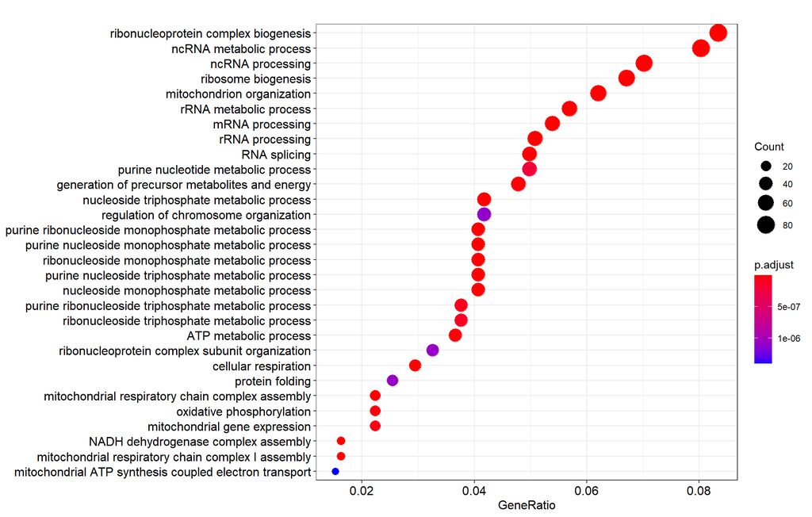

```r
> dotplot(ego, showCategory=30)
```

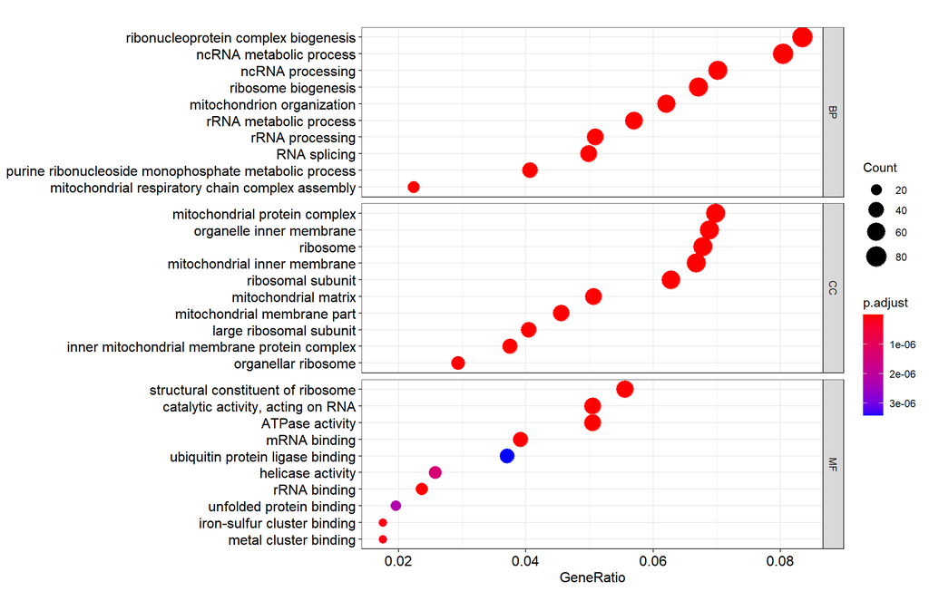

```r
> go <- enrichGO(gene, OrgDb = "org.Mm.eg.db", ont="all")
> dotplot(go, split="ONTOLOGY") + facet_grid(ONTOLOGY~., scale="free")
```

### Visualización de clústers mediante cnetplot

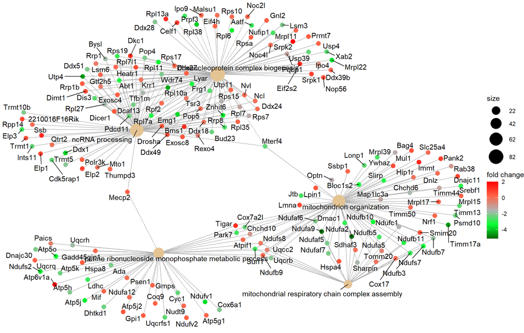

```r
> ego2 <- simplify(ego)
> cnetplot(ego2, foldChange=geneList)
```

### KEGG set enrichment using clusterProfiler

```r
> kk <- enrichKEGG(gene = gene, organism = "mmu", pvalueCutoff = 0.05)
> head(kk)
```

|  | ID | Description | GeneRatio | BgRatio | pvalue | p.adjust | qvalue | geneID | Count |
| --- | --- | --- | --- | --- | --- | --- | --- | --- | --- |
| mmu05012 | mmu05012 | Parkinson disease | 57/459 | 247/8775 | 2.116513e-22 | 5.989732e-20 | 5.547492e-20 | 22145/66108/59029/72900/17991/69077/17995/73710/19173/19170/…… | 57 |
| mmu03010 | mmu03010 | Ribosome | 42/459 | 175/8775 | 2.181157e-17 | 3.086337e-15 | 2.858463e-15 | 19896/20068/66489/67427/20115/27050/19899/67671/20084/67025/…… | 42 |
| mmu00190 | mmu00190 | Oxidative phosphorylation | 36/459 | 133/8775 | 7.358811e-17 | 6.941812e-15 | 6.429277e-15 | 66108/11984/72900/17991/17995/28080/57423/75406/71679/226646…… | 36 |
| mmu05016 | mmu05016 | Huntington disease | 46/459 | 268/8775 | 4.449123e-13 | 3.147754e-11 | 2.915346e-11 | 231329/22145/66108/72900/17991/17995/73710/28080/75406/71679…… | 46 |
| mmu04932 | mmu04932 | Non-alcoholic fatty liver disease (NAFLD) | 32/459 | 150/8775 | 5.118315e-12 | 2.896967e-10 | 2.683075e-10 | 66108/72900/17991/17995/20787/75406/226646/104130/66576/20463/18706/66218/67680/26408/68342/225887/66495/66594/68202/66694/66414/66916/22272/12702/12861/67530/66046/72674/11911/66445/66377/18708 | 32 |
| mmu04714 | mmu04714 | Thermogenesis | 40/459 | 230/8775 | 1.068575e-11 | 5.040113e-10 | 4.667987e-10 | 66108/72900/17991/17995/28080/57423/75406/71679/226646/10413…… | 40 |

```r
> kk2 <- gseKEGG(geneList = geneList,organism = "mmu", nPerm = 1000,
+                minGSSize = 120, pvalueCutoff = 0.05)
> head(kk2)
```

|  | ID | Description | setSize | enrichmentScore | NES | pvalue | p.adjust | qvalues | rank | leading_edge | core_enrichment |
| --- | --- | --- | --- | --- | --- | --- | --- | --- | --- | --- | --- |
| mmu05012 | mmu05012 | Parkinson disease | 218 | -0.5257865 | -1.606830 | 0.001066098 | 0.01711111 | 0.001403509 | 4016 | tags=30%, list=9%, signal=28% | 67089/13665/12858/12367/227613/227197/17993/22151/54405/2644…… |
| mmu04714 | mmu04714 | Thermogenesis | 209 | -0.4898015 | -1.492122 | 0.003225806 | 0.01711111 | 0.001403509 | 5287 | tags=32%, list=12%, signal=28% | 68493/66152/50721/66052/67130/68202/68198/12862/110323/12913…… |
| mmu04932 | mmu04932 | Non-alcoholic fatty liver disease (NAFLD) | 141 | -0.5017401 | -1.476872 | 0.005720824 | 0.01711111 | 0.001403509 | 4011 | tags=33%, list=9%, signal=30% | 68465/66152/66052/67130/68202/68198/12862/26414/56637/110323…… |
| mmu04071 | mmu04071 | Sphingolipid signaling pathway | 120 | 0.5658919 | 2.125281 | 0.006896552 | 0.01711111 | 0.001403509 | 6174 | tags=28%, list=14%, signal=24% | 26416/54447/14678/26408/110157/18798/19877/14673/14674/14677…… |
| mmu04611 | mmu04611 | Platelet activation | 120 | 0.5241317 | 1.968445 | 0.006896552 | 0.01711111 | 0.001403509 | 7874 | tags=30%, list=17%, signal=25% | 19046/26416/14678/19045/69632/18798/19877/14674/14677/14674/…… |
| mmu05135 | mmu05135 | Yersinia infection | 121 | 0.6000976 | 2.254960 | 0.006993007 | 0.01711111 | 0.001403509 | 8126 | tags=29%, list=18%, signal=24% | 26416/69632/19877/68652/26420/26398/18035/19877/23797/11845/…… |

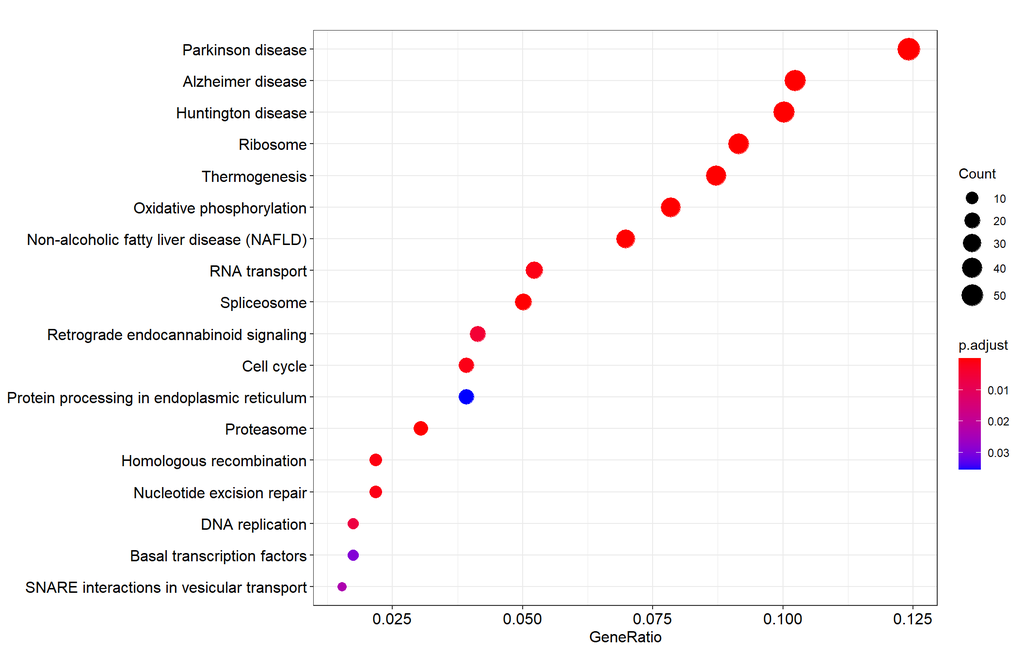

```r
> dotplot(kk, showCategory=20)
```

```r
> wnt <- pathview(gene.data = geneList,
+                 pathway.id = "mmu04310",
+                 species = "mmu",
+                 limit = list(gene=max(abs(geneList)), cpd=1))
>
> ampk <- pathview(gene.data = geneList,
+                  pathway.id = "mmu04152",
+                  species = "mmu",
+                  limit = list(gene=max(abs(geneList)), cpd=1))
>
> pi3pakt <- pathview(gene.data = geneList,
+                     pathway.id = "mmu04151",
+                     species = "mmu",
+                     limit = list(gene=max(abs(geneList)), cpd=1))
>
> mapkinasa <- pathview(gene.data = geneList,
+                       pathway.id = "mmu04010",
+                       species = "mmu",
+                       limit = list(gene=max(abs(geneList)), cpd=1))
>
> oxpho <- pathview(gene.data = geneList,
+                   pathway.id = "mmu00190",
+                   species = "mmu",
+                   limit = list(gene=max(abs(geneList)), cpd=1))
>
> ribo <- pathview(gene.data = geneList,
+                  pathway.id = "mmu03010",
+                  species = "mmu",
+                  limit = list(gene=max(abs(geneList)), cpd=1))
```

### Segundo enfoque de GO/KEGG

El objeto “dat.s” contiene solo los genes diferencialmente expresados. A partir de ahí se trabajará con el objeto “myids”, que consta de todos los probes que hemos considerado interesantes para el estudio. El test que llevaremos a cabo ahora consiste en 3 pasos, ya que la jerarquía de Gene Ontology (GO) consiste en tres diferentes ontologías: procesos biológicos (BP), función molecular (MF) y componente celular (CC).Estos comandos utilizan el pvalor de 0.05 para realizar el análisis de los datos.

```r
> rn <- rownames(topTable(fit.main, n=100))
> tt <- topTable(fit.main, n=nrow(ovo.rma))
> rn <- rownames(tt)[tt$P.Value<=0.001]
> dat.s <- ovo.rma[rn,]
> head(dat.s)
```

```
             GermVes1 GermVes2 GermVes3     MII1     MII2     MII3
1433984_a_at 10.26365 10.15436 10.17803 3.853348 3.937798 3.981797
1456012_x_at 12.01688 12.08720 12.15211 5.981015 5.970370 5.808870
1438179_s_at 13.19012 13.16334 13.13278 7.811837 7.718080 7.832707
1437510_x_at 11.47459 11.74125 11.52850 4.680788 4.907036 4.580200
1429627_at   10.24633 10.40971 10.19094 3.891292 3.970757 3.633696
1433552_a_at 11.27960 11.45303 11.29181 5.567078 5.759502 5.448151
```

```r
> aallg <- get("mouse4302ENTREZID")
> allg <- as.data.frame(unlist(as.list(aallg)))
> myids <- unique(allg[rownames(dat.s),])
```

```r
> paramsBP <- new("GOHyperGParams", geneIds = myids,
+                 annotation = c("mouse4302.db"), ontology = "BP", pvalueCutoff = 0.05,
+                 conditional = FALSE, testDirection = "over")
> resultBP <- hyperGTest(paramsBP)
> paramsMF <- new("GOHyperGParams", geneIds = myids,
+                 annotation = c("mouse4302.db"), ontology = "MF", pvalueCutoff = 0.05,
+                 conditional = FALSE, testDirection = "over")
> resultMF <- hyperGTest(paramsMF)
> paramsCC <- new("GOHyperGParams", geneIds=myids,
+                 annotation = c("mouse4302.db"), ontology = "CC", pvalueCutoff = 0.05,
+                 conditional = FALSE, testDirection = "over")
> resultCC <- hyperGTest(paramsCC)
```

Se guardarán los resultados en una tabla Html para poder visualizar las funciones metabólicas/celulares y significado biológico.

```r
> htmlReport(resultBP, "hypergeo.html", append=T)
> htmlReport(resultMF, "hypergeo.html", append=T)
> htmlReport(resultCC, "hypergeo.html", append=T)
```